# Script 5: Correlations Part 2

Ana-Maria Plesca

2023-04-11

# Introduction

Welcome to the fifth week of statistics with R. This week we will continue learning about correlations, but you will be the one doing most of the work.I am still strongly recommending you to take a look at Chapter 6 in Andy Field’s book Discovering Statistics with R.

# Learning objectives

1. Gain more confidence in using difference correlation tests.
2. Enrich scatterplot-drawing skills.
3. Achieve a very good understanding of bivariate correlations.

# Script prep

Loading packages

```r
library(Hmisc)
library(ggplot2)
library(polycor)
library(tidyverse)
library(nortest)
options(scipen = 999)
```

Setting up the working directory

```r
setwd("~/Desktop/Stats planning/Script 5") # please adjust this path
```

# Bivariate correlation

We’ll have a look at another example of bivariate correlation, using **exam anxiety data coming from 103 students** (Train your reflex to keep in mind the size of the sample you are working with - this helps you figure out which statistical tests are better suited for your data).

```r
examAnxiety <- haven::read_sav("Exam Anxiety.sav")
examAnxiety
```

```
## # A tibble: 103 × 5
##     Code Revise  Exam Anxiety Gender
##    <dbl>  <dbl> <dbl>   <dbl> <dbl+lbl>
##  1     1      4    40    86.3 1 [Male]
##  2     2     11    65    88.7 2 [Female]
##  3     3     27    80    70.2 1 [Male]
##  4     4     53    80    61.3 1 [Male]
##  5     5      4    40    89.5 1 [Male]
##  6     6     22    70    60.5 2 [Female]
##  7     7     16    20    81.5 2 [Female]
##  8     8     21    55    75.8 2 [Female]
##  9     9     25    50    69.4 2 [Female]
## 10    10     18    40    82.3 2 [Female]
## # … with 93 more rows
```

The variables we will be working with are:

- Time spent revising for the exam (expressed in hours) - see column **Revise**
- Exam performance (expressed in percentages) - see column **Exam**
- Exam anxiety (expressed in scores out of 100) - see column **Anxiety**
- Gender -see column **Gender**

Note: The **Code** column represents the participant number.

As you know already, before we even begin conducting our analysis, we need to specifically state our hypotheses about the data.

1. As anxiety increases, exam performance will decrease.
2. The more time was spent revising, the more the exam performance will increase.

What does this tell you about the hypotheses? Think about this to prepare for the correlation tests.

## Scatterplots and regression lines

By now you already know how to draw scatterplots both with `ggplot()` and without (simply using the `plot()` function call and supplying two numerical variables). We will now add to your scatterplott-related knowledge a new element: **a regression line**.

When we add such a regression line to a `ggplot()` scatterplot, we in fact add a *smoothing* element to it using the `geom_smooth()` function. What this does is adds a line that summarizes the relationship between the variables, it smooths out all data points into a line. We won’t yet go into the details of regression, but for now, think of a regression line, as a summary of the relationship between two variables.

Let’s put this in practice.

### Example: Plotting a scatterplot of anxiety by exam performance

To create scatterplots you essentially need to add the `geom_point()` layer to the `ggplot()` geometric structure. We will add the regression line that summarizes the relationship between anxiety and exam performance with the `geom_smooth()` layer, and the argument: `method = lm`. We are instructing the `geom_smooth` layer to add a line, and the chosen method is that of a linear model (abbreviated as `lm`)

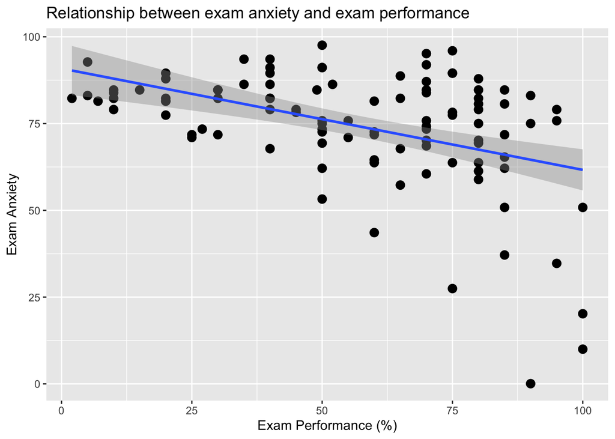

```r
ggplot(examAnxiety, aes(Exam, Anxiety))+
geom_point(size = 3) +
geom_smooth(method = "lm") +
labs(x = "Exam Performance (%)", y = "Exam Anxiety",
     title = "Relationship between exam anxiety and exam performance")
```

The regression line is surrounded by the 95% confidence interval (the grey area). If you want to keep the regression line only, please supply one more argument to the geom_smooth() layer: `se = F` (which is short for ‘standard error = False’).

Furthermore, you can adjust the color of the regression line, to make it stand out more.

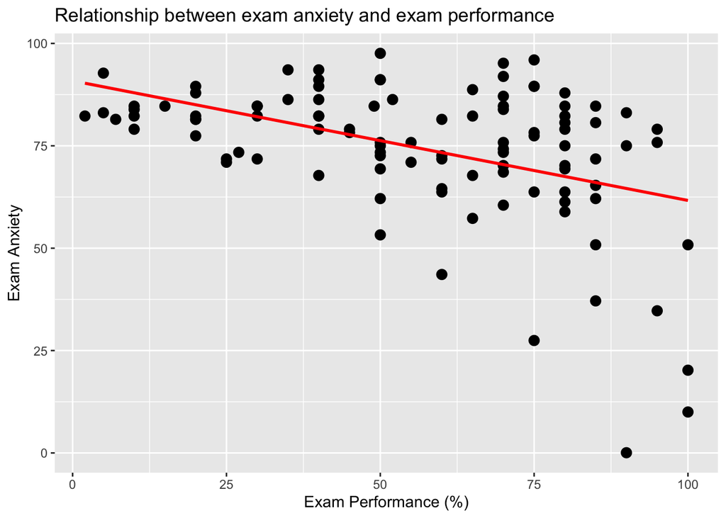

```r
ggplot(examAnxiety, aes(Exam, Anxiety))+
geom_point(size = 3) +
geom_smooth(method = "lm", color = "red", se = F) + # changed the color of the regression line + switched off CIs based on standard error
labs(x = "Exam Performance (%)", y = "Exam Anxiety",
     title = "Relationship between exam anxiety and exam performance")
```

What does this plot tell you? How would you summarize the relationship between exam anxiety and exam performance?

Solved: This plot describes a negative, fairly strong relationship. We have no correlation coefficient yet to confirm this statement. However, the closer the data points are to the regression line, the stronger their relationship. It seems to be the case that the higher the anxiety, the poorer the exam performance.

### Task 1: Plot a scatterplot of revision time by exam performance

It’s your turn to “draw” a scatterplot describing the relationship between revision time and exam performance. I advise you to not copy & paste the code above. Try to recreate it yourself, as this will help you understand the process.

To complete this task, please add:

- a green-coloured regression line
- a regression line without CI
- labels for the x and y axes and a meaningful title
- a description of the relationship between the two variables

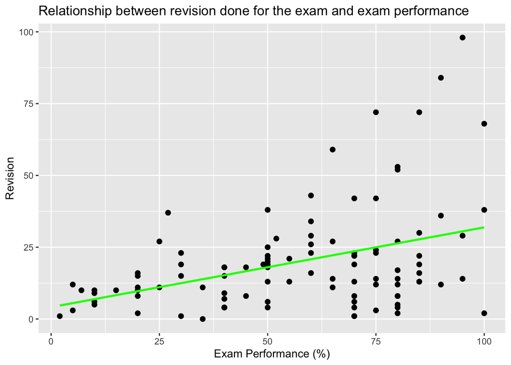

```r
ggplot(examAnxiety, aes(Exam, Revise))+
  geom_point(size = 2)+
  geom_smooth(method = "lm", color = "green", se = F) +
  labs(x = "Exam Performance (%)", y = "Revision",
     title = "Relationship between revision done for the exam and exam performance")
```

### How to use the regression line to predict scores?

In SPSS, the value of the regression line is conveniently provided with the plot and you had no issue computing the predicted anxiety score for an exam score of 80. How do we do that in R? Don’t worry if what follows will feel a bit too complicated. At this step, you only need to understand how we can achieve this information with R.

**Step 1: Building a linear model**

We will use the `lm()` function to build a linear regression model. At this stage we are using it to understand the relationship between exam performance and anxiety.

The arguments (parameters) of `lm()` function:

```r
examAnxiety_lm <- lm(Anxiety ~ Exam, data = examAnxiety)
examAnxiety_lm
```

```
##
## Call:
## lm(formula = Anxiety ~ Exam, data = examAnxiety)
##
## Coefficients:
## (Intercept)         Exam
##     90.8682      -0.2921
```

**Step 2: Extracting the estimated values of the linear model**

The result of fitting the linear model to the data are two estimated values:

1. The intercept - in our case the average estimated anxiety with a value of `90.8682`
2. A slope - tells you how much change in the y-variable (anxiety) is caused by a unit change in x-variable. (exam score) `-0.2921`.

The slope here represents the estimated value for exam score and it informs about how the estimated anxiety would change after a unit-increase in the exam score. In other words, for each 1-point increase in the exam score, the anxiety would drop by -0.2921.

**Step 3: Use the linear model equation and the estimated values from the linear model**

Here’s an exemplified version of the linear model equation:

Yi = β0 + β1*Xi

We are trying to predict Yi, the anxiety of a person i, based on their exam score Xi.  
β0 represents the overall anxiety (the intercept) and β0 the slope estimated value associated with exam score

For an exam score of 80 (that is, Xi = 80), what is the predicted anxiety score? Let’s use the formula and replace the value we already know from the model.

```r
y = 90.8682 + -0.2921 * 80

y
```

```
## [1] 67.5002
```

The predicted anxiety score of a person who obtained an 80% exam performance score is 67.5002.

### Task 2: Predict the anxiety

It’s your turn now. What’s the predicted anxiety score for a person who achieved a 20 exam score?

```r
y = 90.8682 + -0.2921 * 20
y
```

```
## [1] 85.0262
```

- The predicted anxiety score for an exam performance of 20 is 85.02

What can you lean from these values? Put them in relation to the scatterplot you’ve drawn.

- These values confirm our intuitions we have build based on the scatterplots. In the presence of a high level of anxiety, the exam performance drops. By contrast, higher exam performance percentages were associated with lower anxiety scores.

## Task 3: Testing for normality

Our goal is still to compute correlation analyses between exam performance and anxiety, as well as between exam performance and revision. In the next step, we need to test for the assumption of normality so that we can decide what kind of correlation analysis we will conduct.

For each of the following three tasks, please:

1. Draw histograms to show the distribution of the variables. Use either the `hist()` function or the `ggplot()` function.
2. Conduct the appropriate normality test. Keep in mind the sample size (N = 103) when you make the decision. If you need a refresher, take a look at the second week’s script.
3. Report the results of each test

### Task 3.1. : Test anxiety scores for normality

**Histogram describing the distribution of normality scores**

Option 1:

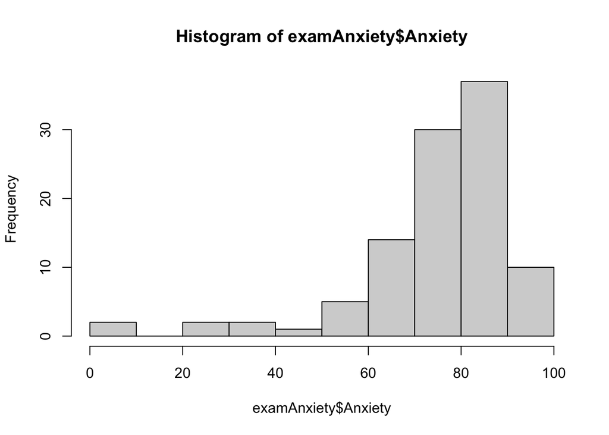

```r
hist(examAnxiety$Anxiety)
```

Option 2:

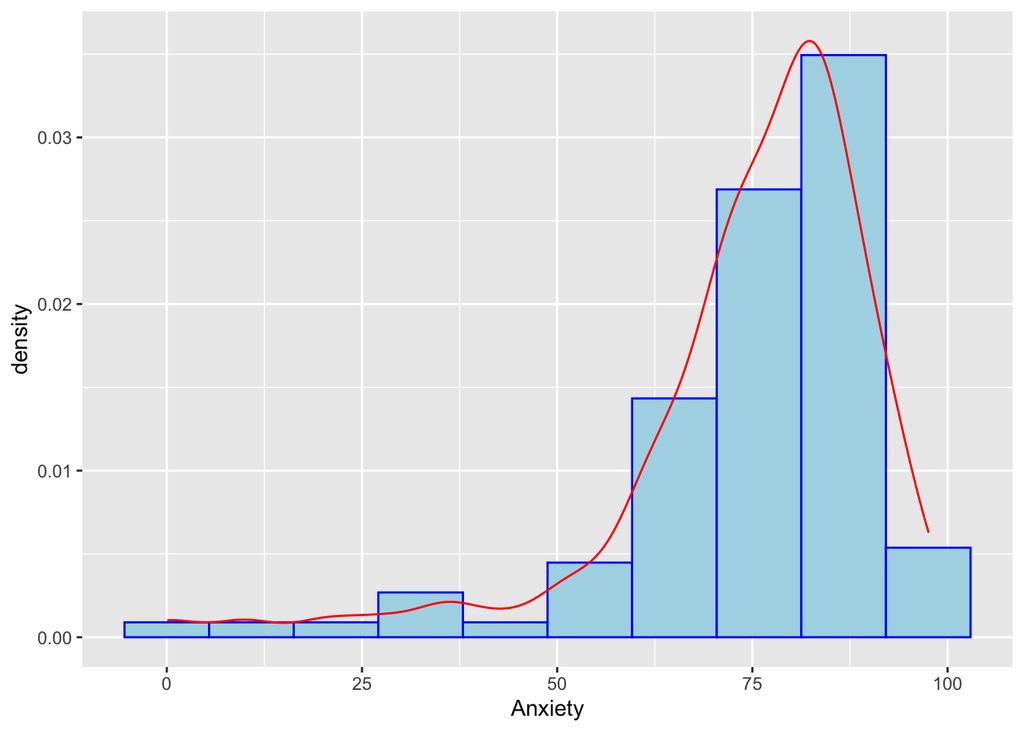

```r
ggplot(data = examAnxiety, aes(x = Anxiety))+
  geom_histogram(aes(y = ..density..),color = "blue", fill = "lightblue", bins = 10)+
  geom_density(color = "red")
```

The anxiety scores are strongly negatively skewed. In other words, high scores of anxiety are highly frequent, whereas low anxiety scores are rare (infrequent).

**Conducting a normality-test**

Since this is a large sample, we will conduct a **Lilliefors-corrected Kolmogorov–Smirnov test**

```r
nortest::lillie.test(examAnxiety$Anxiety)
```

```
##
##  Lilliefors (Kolmogorov-Smirnov) normality test
##
## data:  examAnxiety$Anxiety
## D = 0.15314, p-value = 0.000003083
```

The K-S normality test yielded a significant result *D* = .15, *p* < .001, indicating that the distribution of the anxiety scores differs significantly from normality.

### Task 3.2. : Test exam performance for normality

**Histogram describing the distribution of normality scores**

Option 1:

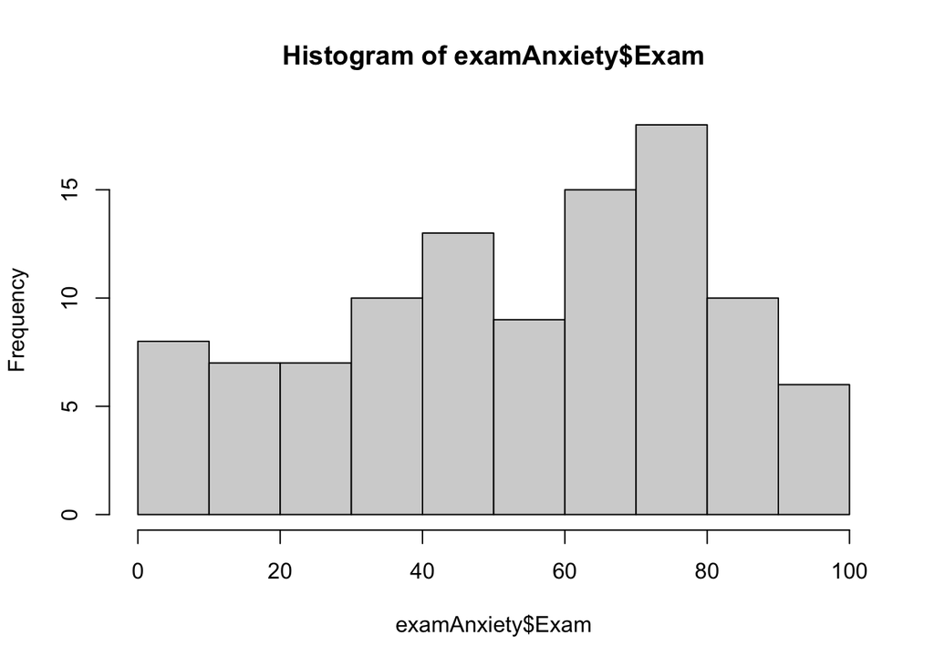

```r
hist(examAnxiety$Exam)
```

Option 2:

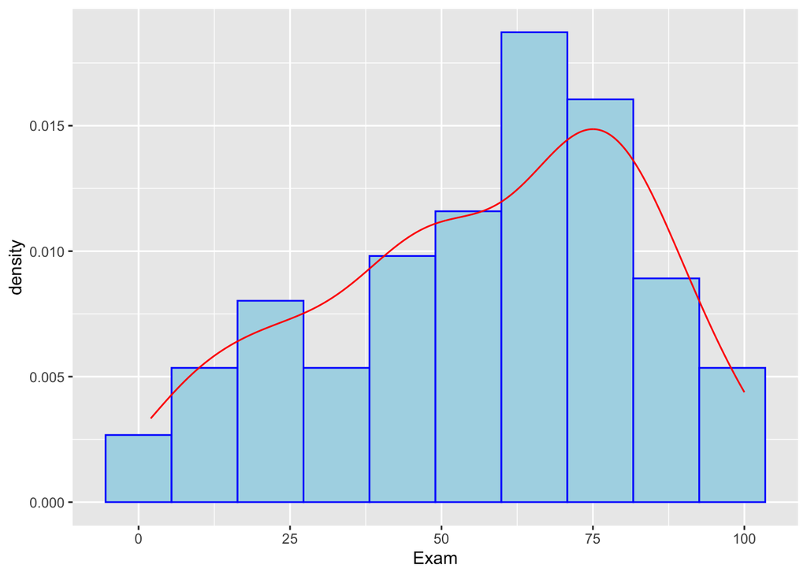

```r
ggplot(data = examAnxiety, aes(x = Exam))+
  geom_histogram(aes(y = ..density..),color = "blue", fill = "lightblue", bins = 10)+
  geom_density(color = "red")
```

The distribution of the exam performance percentages looks mixed, though with a tendency towards a negative skew.

**Conducting a normality-test**

Since this is a large sample, we will conduct a **Lilliefors-corrected Kolmogorov–Smirnov test**

```r
nortest::lillie.test(examAnxiety$Exam)
```

```
##
##  Lilliefors (Kolmogorov-Smirnov) normality test
##
## data:  examAnxiety$Exam
## D = 0.13453, p-value = 0.00009235
```

The K-S normality test yielded a significant result *D* = .13, *p* < .001, indicating that the distribution of the exam performance percentage scores differs significantly from normality.

### Task 3.3. : Test revision for normality

**Histogram describing the distribution of normality scores**

Option 1:

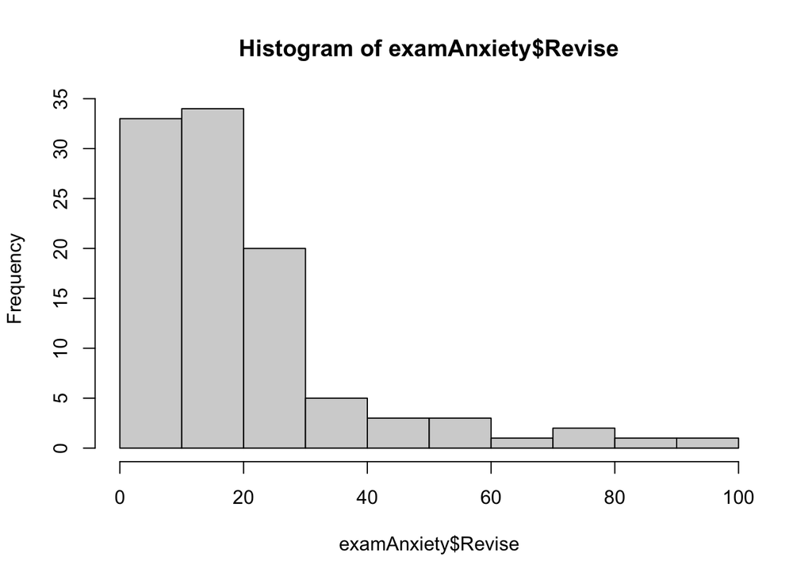

```r
hist(examAnxiety$Revise)
```

Option 2:

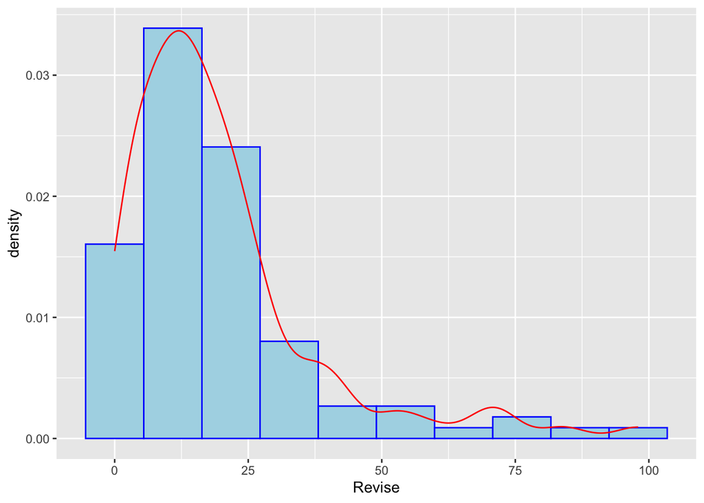

```r
ggplot(data = examAnxiety, aes(x = Revise))+
  geom_histogram(aes(y = ..density..),color = "blue", fill = "lightblue", bins = 10)+
  geom_density(color = "red")
```

The time spent revising is positively skewed, with highly frequent low values are highly frequent and infrequent high values.

**Conducting a normality-test**

Since this is a large sample, we will conduct a **Lilliefors-corrected Kolmogorov–Smirnov test**

```r
nortest::lillie.test(examAnxiety$Revise)
```

```
##
##  Lilliefors (Kolmogorov-Smirnov) normality test
##
## data:  examAnxiety$Revise
## D = 0.17881, p-value = 0.00000001223
```

The K-S normality test yielded a significant result *D* = .17, *p* < .001, indicating that the distribution of the revision scores differs significantly from normality.

## Task 4: Choosing the appropriate correlation test

Based on the results of the previous tasks, you have hopefully reached the conclusion that none of the three variables are normally distributed. Choose the correlation test according to the following criteria:

1. Data is not normally distributed
2. Your sample size is large (N = 103)

Don’t forget the hypotheses we’ve come up in the beginning for each of the two analyses we want to conduct. These are essential for running the analyses:

- **H1:** As *anxiety increases*, *exam performance* will *decrease.* (Anxiety + exam performance correlation)
- **H2:** The *more time was spent revising*, the more the *exam performance will increase*. (Revision + exam performance correlation)

Since none of the variables are normally distributed, I chose to conduct correlation analyses using the Spearman’s rho. Spearman is a non-parametric test and does not require meeting the normality assumption.

```r
# conduct the anxiety-by-exam performance correlation here - one-tailed test + negative relationship (as one increases, one decreases)

cor.test(examAnxiety$Exam, examAnxiety$Anxiety, alternative = "less", method = "spearman")
```

```
## Warning in cor.test.default(examAnxiety$Exam, examAnxiety$Anxiety, alternative
## = "less", : Cannot compute exact p-value with ties
```

```
##
##  Spearman's rank correlation rho
##
## data:  examAnxiety$Exam and examAnxiety$Anxiety
## S = 255786, p-value = 0.00001123
## alternative hypothesis: true rho is less than 0
## sample estimates:
##        rho
## -0.4046141
```

*What does that warning mean? The spearman correlation coefficient works with the rank of values and so the correlation test ignores the same ranks to find the p-values. As a result we get this warning: “Cannot compute exact p-value with ties”. Don’t worry about this.*

Please report the results of the anxiety-by-exam performance correlation here:

```r
# conduct the revision-by-exam performance correlation here
```

Please report the results of the revision-by-exam performance correlation here:

## Task 5: Compute the R^2 value

In the last script we have learned how to compute the **coefficient of determination, R^2**. It indicates the amount of variance in one variable that is accounted for/shared by another variable.

### Task 5.1.: Compute the coefficient of determination, R^2 for anxiety and exam performance

What does the value you have computed mean? Interpret it please.

### Task 5.2.: Compute the coefficient of determination, R^2 for revision and exam performance

What does the value you have computed mean? Interpret it please.

# Correlation continued

Here comes one more correlation exercise based on the the data file “Mydata.sav”. It shows made-up data from managers and from employees about their number of friends, date of birth, their alcohol consumption (in units), their neuroticism scores (the higher the score, the more neurotic), and their annual income in GBP.

Group 1 is represented by managers, Group 2 by employees

```r
employee_manager_data <- haven::read_sav("Mydata.sav")
```

Take a look at the data

```r
head(employee_manager_data)
```

```
## # A tibble: 6 × 7
##   Name   Birth_Date Group        Friends Alcohol Income Neurotic
##   <chr>  <date>     <dbl+lbl>      <dbl>   <dbl>  <dbl>    <dbl>
## 1 Leo    1977-02-17 1 [Manager]        4       8  30000       12
## 2 Martin 1969-05-24 1 [Manager]        7      16  15000       19
## 3 Andy   1973-06-21 1 [Manager]        5      17  35000       16
## 4 Paul   1974-07-16 1 [Manager]        6       7  22000       15
## 5 Graham 1949-10-10 1 [Manager]        2      24  15000       23
## 6 Carina 1983-11-04 2 [Employee]       8      34   9000        9
```

## Task 1: Plot a bar graph

- Plot the mean alcohol consumption on the y-axis,
- Plot the group (managers -1 and employees -2) on the x-axis
- Include error bars (95 percent condence intervals of each mean) - remember which function you need to use?
- Interpret the graph

## Task 2: Plot a scatterplot

- Plot the alcohol consumption on the y-axis
- Plot the on the neuroticism (x-axis)
- The plot should be grouped by Group, that is by manager / employee (We used the layer facet_wrap() to achieve this. It is up to you to remember/figure out how to do it. (We’ve done this before)
- Include the regression line
- Describe the relationship between the two variables

## Task 3: Is there a reliable correlation between alcohol consumption and neuroticism?

- State your hypothesis and its type.
- Run normality analyses (keep in mind the sample size)
- Run a correlation analysis (keep in mind the sample size and the type of data)

## Extra tasks (not obligatory)

- Build subsets for managers and employees
- Run the correlation analyses again. What conclusion have you reached?